# PLOTS

### Overview

- **Study design:** Analytical, prospective dynamic cohort study.
- **Setting:** The data was obtained from a pragmatic, multicentre, individually randomized clinical trial.
- **Study population:** Adults (>18years), HIV-positive patients with no evidence of tuberculosis co-infection, admitted to medical wards at Zomba Central or Edendale Hospital between February 2015 and January 2018, and who provided consent to participate in the parent study.
- **Aim:** To assess whether ART-status, as indicator of (in)appropriate HIV treatment accessibility and management, is leading to higher death rates in hospitalised patients (with no evidence of tuberculosis co-infection) in two main referral hospitals in Malawi and South Africa.
- **Outcome:** All-cause 56-day (8-week) mortality.
- **Main exposure:** ‘ART-status’. A composite variable with three categories, based on ART at admission (yes/no) and CD4 level at admission (low/high) if patient is under ART
- **(1) ART-High CD4** HIV-patients who have started ART and have a high count of CD4 at admission
- **(2) ART-Low CD4** HIV-patients who have started ART and have a low count of CD4 at admission
- **(3) No ART** HIV-patients who have not started ART prior admission

### Dependencies & global settings

```r
# Packages needed
library(tidyverse)
library(gridExtra)
library(knitr)
library(survminer)
library(survival)
library(ggthemes)
# Global settings
knitr::opts_chunk$set(echo = TRUE)
options(width = 100)
```

### Upload / Prepare data

```r
hiv <- read.csv(file="~/hiv/hiv07sep.csv", header = TRUE, sep = ",")

hiv$cd4count   <-as.numeric(hiv$cd4count)
hiv$art3       <-as.factor(hiv$art3)
hiv$art2       <-as.factor(hiv$art2)
hiv$art1       <-as.factor(hiv$art1)
hiv$hivdx00    <-as.numeric(hiv$hivdx00)
hiv$age        <-as.numeric(hiv$age)
hiv$artyears2  <-as.numeric(hiv$artyears2)
hiv$hiv_art_c2 <-as.factor(hiv$hiv_art_c2)

# change the labels for fupreason
levels(hiv$fupreason)
```

```
[1] "1.death"    "2.withdrew" "3.lost_fup" "4.complete"
```

```r
# Initially used plyr::revalue because I incorrecly imported this as a factor
# I want to correct this now so I can use dplyr only
# So, I collaps two levels first and then recode the rest.
hiv$fupreason2 <- fct_collapse(hiv$fupreason, Censored = c("2.withdrew","3.lost_fup"))
levels(hiv$fupreason2)
```

```
[1] "1.death"    "Censored"   "4.complete"
```

```r
hiv$fupreason2 <- fct_recode(hiv$fupreason2, Outcome = "1.death", Complete = "4.complete")
# checking relabeling worked
table(hiv$fupreason, hiv$fupreason2, useNA = "always")
```

```
             Outcome Censored Complete <NA>
  1.death        311        0        0    0
  2.withdrew       0        1        0    0
  3.lost_fup       0       37        0    0
  4.complete       0        0     1712    0
  <NA>             0        0        0    0
```

### Plots settings

```r
fill <- "slategray"
line <- "#1F3552"
cate <- c("https://protect-eu.mimecast.com/s/ohJjCD8vnCmwWJHAJiic?domain=1.art" = "steelblue4",
          "https://protect-eu.mimecast.com/s/WODaCExwoHGOz0HPaHp2?domain=2.art" = "skyblue3",
          "3.noART" = "Grey60")

t <-theme(panel.background   = element_rect(fill = "white", colour = "grey"),
          panel.grid.minor.y = element_blank(),
          panel.grid.major.y = element_line(colour = "grey", size = 0.15),

          axis.ticks.x = element_blank(),
          axis.ticks.y = element_blank(),

          axis.text.x = element_text(colour = "grey27", size = 9),
          axis.title.y = element_text(colour = "grey27", size = 10),

          plot.margin = unit(c(1, 3, 1, 3), "cm"),
          plot.background = element_rect(colour = "black", fill = "grey90", size = 0.1))
```

### Box plot 1 - Basic

Time LHIV (years) over exposure

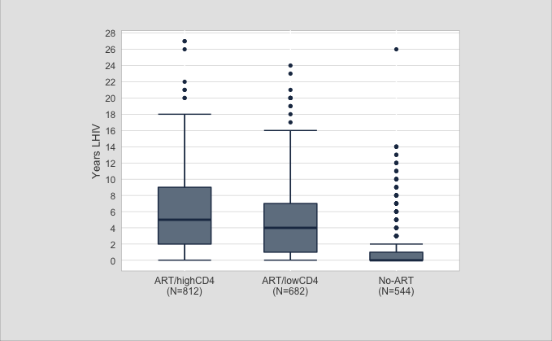

```r
ggplot(data    = hiv,
       mapping = aes(x = artstatus1, y = hivdxyears)) +
  # add the wiskers
  stat_boxplot(geom ='errorbar', width = 0.5, colour = line) +
  # add this layer at the end so it shows over the error bar line
  geom_boxplot(fill = fill, colour = line, width = 0.5,
               outlier.colour = line, outlier.shape = 16) +
  # labels for the axes and axes labels
  scale_x_discrete(name = " ", labels = c('ART/highCD4\n(N=812)',
                                          'ART/lowCD4\n(N=682)',
                                          'No-ART\n(N=544)')) +
  scale_y_continuous(name = "Years LHIV", breaks = seq(0, 28, 2)) +
  # add the theme
  t
```

### Box plot 2 - Adding elements

CD4 count (cells/ml) by time of HIV diagnosis amongst no-ART

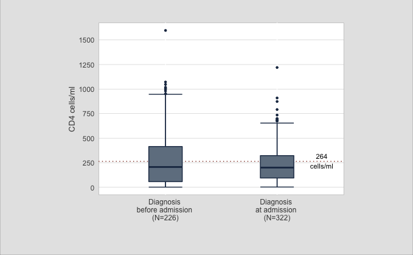

```r
ggplot(data    = subset(hiv, !is.na(art3)),
       mapping = aes(x = art3, y = cd4count))  +
  # add the wiskers
  stat_boxplot(geom ='errorbar', width = 0.3, colour = line) +
  # add the line used to dicotomise main exposure
  geom_hline(yintercept = 264, linetype = "dotted", color = "tomato4", size = 0.5) +
  # add this layer at the end so it shows over the dotted line
  geom_boxplot(fill = fill, colour = line, width = 0.3,
               outlier.colour = line, outlier.shape = 20) +
  # labels for the axes and axes labels
  scale_x_discrete(name = " ", labels = c('Diagnosis \nbefore admission \n(N=226)',
                                          'Diagnosis \nat admission \n(N=322)')) +
  scale_y_continuous(name = "CD4 cells/ml", breaks = seq(0, 1800, 250)) +
  # additional text for the label
  annotate("text", x = 2.4, y = 269, label = "264\ncells/ml", size = 3 ) +
  # add the theme
  t
# save the plot
ggsave("cd4.png", width = 15, height = 10, units = "cm")
```

### Scatterplot 1 - Overide global settings

Time LHIV on time on ART.

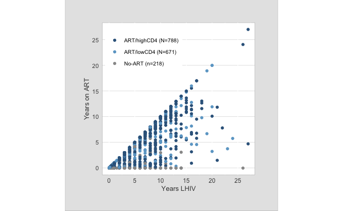

```r
ggplot(data    = hiv,
       mapping = aes(x = hivdxyears, y = artyears2, colour = factor(artstatus1))) +
  geom_point()  +
  # use the colors defined in "settings" and define new labels for the strata
  scale_colour_manual(values = cate,
                      breaks = c("https://protect-eu.mimecast.com/s/ohJjCD8vnCmwWJHAJiic?domain=1.art",
                                 "https://protect-eu.mimecast.com/s/WODaCExwoHGOz0HPaHp2?domain=2.art",
                                 "3.noART"),
                      labels = c("ART/highCD4 (N=788)",
                                 "ART/lowCD4 (N=671)",
                                 "No-ART (n=218)")) +
  # labels and breaks for the axes
  scale_x_continuous(name = "Years LHIV",
                     breaks = seq(0, 30, 5)) +
  scale_y_continuous(name = "Years on ART",
                     breaks = seq(0, 30, 5)) +
  ## same scale for both axes
  coord_equal() +
  # using the same theme but overiding some parameters and adding others
  # note I have to use axis.tilte instead of axis.text to override
  t +
  theme(axis.title.x = element_text(colour = "Grey27", size = 10),

        legend.key = element_blank(),
        legend.title = element_blank(),
        legend.position = c(0.02, 0.97),
        legend.justification = c(0, 1),
        legend.text = element_text(size = 8),

        plot.margin = unit(c(1.2, 1.2, 1, 1), "cm")
)
```

### Scatterplot 2 - Faceting

Follow-up time by main exposure and censoring

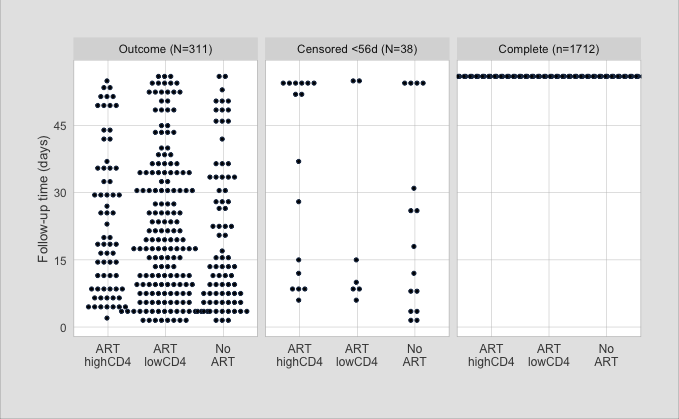

```r
# savign and object withthe labels for the graph
fupreason2.labs <- c('Outcome'  = "Outcome (N=311)",
                     'Censored' = "Censored <56d (N=38)",
                     'Complete' = "Complete (n=1712)")
ggplot(data = hiv,
       mapping = aes(x= artstatus1, y=fuptime2)) +
  geom_dotplot(binaxis = "y", stackdir = "center",
               stackratio = 1.5, dotsize = 0.5,
               colour = line) +
  # faceting
  facet_wrap(~ fupreason2,
             ncol = 3,
             labeller = labeller(fupreason2 = fupreason2.labs))  +
  # labels and breaks for the axes
  scale_x_discrete(name = " ", labels = c('ART\nhighCD4',
                                          'ART\nlowCD4',
                                          'No\nART'))  +
  scale_y_continuous(name   = "Follow-up time (days)",
                     breaks = seq(0, 70, 15)) +
  # using the same theme but overiding some parameters and adding others
  # again using axis.title instead of axis.text to override
  t +
  theme(panel.grid.major.x = element_line(colour = "grey", size = 0.15),
        axis.title.x = element_text(colour = "Grey27", size = 8),
        plot.margin = unit(c(1, 1, 1, 1), "cm"))
```

### Survival curves

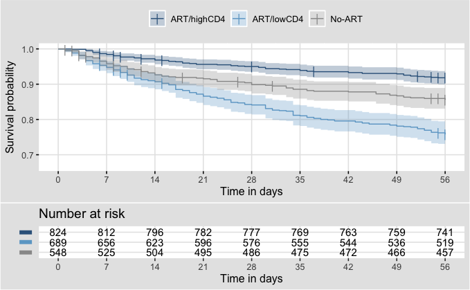

```r
# survival::survfit --> creates the survfit object needed for ggsurvplot
fit1 <-survfit(Surv(fuptime2, died) ~ artstatus1,
               data = hiv)
# survminer::ggsurvplot creates the plot
ggsurvplot(fit1,
           censor.shape = "|", censor.size = 4,
           size = 0.5,
           palette =  c("steelblue4","skyblue3","Grey60"),
           conf.int = TRUE,

           risk.table = TRUE,
           risk.table.y.text = FALSE,
           risk.table.height = 0.3, # this is the proportion of hight it takes
           risk.table.fontsize = 4,

           legend.title = " ",
           legend.labs = c('ART/highCD4', 'ART/lowCD4', 'No-ART'),
           legend = "top",

           ylim = c(0.67, 1.00),
           xlim = c(0,56),
           break.time.by = 7,
           xlab = "Time in days",
           ggtheme = theme_igray()
           )
```